# Machine Learning Course project

Javier Iglesia Aparicio

3 de enero de 2017

# Introduction

## Background

Using devices such as Jawbone Up, Nike FuelBand, and Fitbit it is now possible to collect a large amount of data about personal activity relatively inexpensively. These type of devices are part of the quantified self movement – a group of enthusiasts who take measurements about themselves regularly to improve their health, to find patterns in their behavior, or because they are tech geeks. One thing that people regularly do is quantify how much of a particular activity they do, but they rarely quantify how well they do it. In this project, your goal will be to use data from accelerometers on the belt, forearm, arm, and dumbell of 6 participants. They were asked to perform barbell lifts correctly and incorrectly in 5 different ways. More information is available from the website here: http://groupware.les.inf.puc-rio.br/har (see the section on the Weight Lifting Exercise Dataset).

## Goal

The training data for this project are available here: https://d396qusza40orc.cloudfront.net/predmachlearn/pml-training.csv

The test data are available here: https://d396qusza40orc.cloudfront.net/predmachlearn/pml-testing.csv

The data for this project come from this source: http://groupware.les.inf.puc-rio.br/har.

```r
set.seed(12344)
#Loading required libraries
library(dplyr)
library(caret)
library(ggplot2)
library(randomForest)
library(rpart)
library(rpart.plot)
library(rattle)

#Reading datasets
training <- read.csv("pml-training.csv", na.strings=c("NA","#DIV/0!",""))
testing <- read.csv("pml-testing.csv", na.strings=c("NA","#DIV/0!",""))
# Then I look into the training data
str(training)
```

```
## 'data.frame':    19622 obs. of  160 variables:
##  $ X                       : int  1 2 3 4 5 6 7 8 9 10 ...
##  $ user_name               : Factor w/ 6 levels "adelmo","carlitos",..: 2 2 2 2 2 2 2 2 2 2 ...
##  $ raw_timestamp_part_1    : int  1323084231 1323084231 1323084231 1323084232 1323084232 1323084232 1323084232 1323084232 1323084232 1323084232 ...
##  $ raw_timestamp_part_2    : int  788290 808298 820366 120339 196328 304277 368296 440390 484323 484434 ...
##  $ cvtd_timestamp          : Factor w/ 20 levels "02/12/2011 13:32",..: 9 9 9 9 9 9 9 9 9 9 ...
##  $ new_window              : Factor w/ 2 levels "no","yes": 1 1 1 1 1 1 1 1 1 1 ...
##  $ num_window              : int  11 11 11 12 12 12 12 12 12 12 ...
##  $ roll_belt               : num  1.41 1.41 1.42 1.48 1.48 1.45 1.42 1.42 1.43 1.45 ...
##  $ pitch_belt              : num  8.07 8.07 8.07 8.05 8.07 8.06 8.09 8.13 8.16 8.17 ...
##  $ yaw_belt                : num  -94.4 -94.4 -94.4 -94.4 -94.4 -94.4 -94.4 -94.4 -94.4 -94.4 ...
##  $ total_accel_belt        : int  3 3 3 3 3 3 3 3 3 3 ...
##  $ kurtosis_roll_belt      : num  NA NA NA NA NA NA NA NA NA NA ...
##  $ kurtosis_picth_belt     : num  NA NA NA NA NA NA NA NA NA NA ...
##  $ kurtosis_yaw_belt       : logi  NA NA NA NA NA NA ...
```

[output cut: 86 more lines]

```r
# This the variable we should predict
summary(training$classe)
```

```
##    A    B    C    D    E
## 5580 3797 3422 3216 3607
```

# Developing the prediction

We have to predict the *classe* variable. It is a factor variable with five different values: exactly according to the specification (Class A), throwing the elbows to the front (Class B), lifting the dumbbell only halfway (Class C), lowering the dumbbell only halfway (Class D) and throwing the hips to the front (Class E).

Read more: http://groupware.les.inf.puc-rio.br/har#ixzz4V6FsbwcA

## Partitioning the original training data

We will split the original training data into a “training” set and a “validation” set. The training subset will include 80% of the observations and the remaining will be used to calculate the out-of-sample error.

```r
inTrain <- createDataPartition(training$classe, p=0.8, list=FALSE)
myTraining <- training[inTrain, ]
myTesting <- training[-inTrain, ]
dim(myTraining); dim(myTesting)
```

```
## [1] 15699   160
```

```
## [1] 3923  160
```

## Cleaning and transforming data

If we inspect the dataset, we can see a lot of variables without data or not concerning the movement data. So, first we are going to remove these variables:

```r
#Removing X and user_name columns
myTraining <- myTraining %>% select(-X) %>% select (-user_name)
myTesting <- myTesting %>% select(-X) %>% select (-user_name)
#Removing timestamp and window columns not contains sensor measurement data
myTraining <- myTraining %>% select(-contains("window")) %>% select(-contains("timestamp"))
myTesting <- myTesting %>% select(-contains("window")) %>% select(-contains("timestamp"))
#Determining Near Zero Variance Variables
nearzerovars<- nearZeroVar(myTraining, saveMetrics = TRUE)
myTraining<- myTraining[,nearzerovars$nzv==FALSE]

nearzerovars<- nearZeroVar(myTesting, saveMetrics = TRUE)
myTesting<- myTesting[,nearzerovars$nzv==FALSE]
#Last, we drop columns with all o majority NA values
variableNAs <- colMeans(is.na(myTraining))
myTraining <- myTraining[!variableNAs]

variableNAs <- colMeans(is.na(myTesting))
myTesting <- myTesting[!variableNAs]
```

So, finally, we will use 53 variables.

## Model 1: Decision Trees

First we try a decision tree model.

```r
modDecTree <- rpart(classe~., data=myTraining, method="class")
print(modDecTree)
```

```
## n= 15699
##
## node), split, n, loss, yval, (yprob)
##       * denotes terminal node
##
##     1) root 15699 11235 A (0.28 0.19 0.17 0.16 0.18)
##       2) roll_belt< 130.5 14387  9932 A (0.31 0.21 0.19 0.18 0.11)
##         4) pitch_forearm< -33.95 1258     8 A (0.99 0.0064 0 0 0) *
##         5) pitch_forearm>=-33.95 13129  9924 A (0.24 0.23 0.21 0.2 0.12)
##          10) magnet_dumbbell_y< 436.5 11068  7938 A (0.28 0.18 0.24 0.19 0.11)
##            20) roll_forearm< 122.5 6857  4048 A (0.41 0.18 0.18 0.17 0.06)
##              40) magnet_dumbbell_z< -25.5 2350   756 A (0.68 0.2 0.016 0.075 0.033)
##                80) roll_forearm>=-136.5 1960   404 A (0.79 0.16 0.016 0.024 0.0066) *
##                81) roll_forearm< -136.5 390   237 B (0.097 0.39 0.013 0.33 0.16) *
##              41) magnet_dumbbell_z>=-25.5 4507  3287 C (0.27 0.17 0.27 0.21 0.074)
##                82) yaw_belt>=168.5 605    97 A (0.84 0.084 0 0.073 0.0033) *
##                83) yaw_belt< 168.5 3902  2682 C (0.18 0.18 0.31 0.24 0.085)
##                 166) accel_dumbbell_y>=-40.5 3382  2480 D (0.21 0.21 0.23 0.27 0.092)
##                   332) pitch_belt< -43.15 361    47 B (0.014 0.87 0.075 0.019 0.022) *
##                   333) pitch_belt>=-43.15 3021  2126 D (0.23 0.13 0.24 0.3 0.1)
##                     666) roll_belt>=125.5 732   301 C (0.36 0.038 0.59 0.015 0.0027)
##                      1332) magnet_belt_z< -322.5 228     9 A (0.96 0.0044 0.026 0 0.0088) *
##                      1333) magnet_belt_z>=-322.5 504    79 C (0.081 0.054 0.84 0.022 0) *
##                     667) roll_belt< 125.5 2289  1405 D (0.19 0.16 0.13 0.39 0.13)
##                      1334) pitch_belt>=1.305 1443  1111 A (0.23 0.22 0.14 0.22 0.19)
##                        2668) accel_dumbbell_z< 31.5 938   625 A (0.33 0.15 0.21 0.26 0.037)
##                          5336) yaw_forearm>=-94.65 673   360 A (0.47 0.2 0.23 0.064 0.04)
##                           10672) magnet_forearm_z>=-92.5 416   113 A (0.73 0.14 0.014 0.087 0.026) *
##                           10673) magnet_forearm_z< -92.5 257   109 C (0.039 0.3 0.58 0.027 0.062) *
##                          5337) yaw_forearm< -94.65 265    60 D (0 0.026 0.17 0.77 0.03) *
##                        2669) accel_dumbbell_z>=31.5 505   266 E (0.038 0.36 0.0059 0.12 0.47)
##                          5338) roll_dumbbell< 36.70066 157    28 B (0.032 0.82 0.019 0.045 0.083) *
##                          5339) roll_dumbbell>=36.70066 348   122 E (0.04 0.15 0 0.16 0.65) *
##                      1335) pitch_belt< 1.305 846   273 D (0.12 0.039 0.13 0.68 0.033) *
##                 167) accel_dumbbell_y< -40.5 520    67 C (0.0096 0.04 0.87 0.038 0.04) *
##            21) roll_forearm>=122.5 4211  2815 C (0.076 0.18 0.33 0.23 0.19)
##              42) magnet_dumbbell_y< 290.5 2467  1264 C (0.092 0.13 0.49 0.15 0.14)
##                84) magnet_dumbbell_z>=285 360   179 A (0.5 0.14 0.047 0.078 0.23) *
##                85) magnet_dumbbell_z< 285 2107   921 C (0.022 0.13 0.56 0.16 0.13)
##                 170) pitch_belt>=26.15 163    33 B (0.098 0.8 0.037 0 0.067) *
##                 171) pitch_belt< 26.15 1944   764 C (0.016 0.075 0.61 0.17 0.13) *
##              43) magnet_dumbbell_y>=290.5 1744  1143 D (0.053 0.24 0.11 0.34 0.25)
##                86) accel_forearm_x>=-101.5 1126   736 E (0.047 0.31 0.15 0.15 0.35)
##                 172) magnet_arm_y>=195.5 458   210 B (0.013 0.54 0.22 0.1 0.12) *
##                 173) magnet_arm_y< 195.5 668   335 E (0.07 0.15 0.1 0.18 0.5) *
##                87) accel_forearm_x< -101.5 618   181 D (0.065 0.11 0.039 0.71 0.074) *
##          11) magnet_dumbbell_y>=436.5 2061  1015 B (0.036 0.51 0.041 0.23 0.19)
##            22) total_accel_dumbbell>=5.5 1470   515 B (0.051 0.65 0.056 0.022 0.22)
##              44) roll_belt>=-0.565 1244   289 B (0.06 0.77 0.067 0.026 0.08) *
##              45) roll_belt< -0.565 226     0 E (0 0 0 0 1) *
##            23) total_accel_dumbbell< 5.5 591   152 D (0 0.15 0.0034 0.74 0.1) *
##       3) roll_belt>=130.5 1312     9 E (0.0069 0 0 0 0.99) *
```

The plot is:

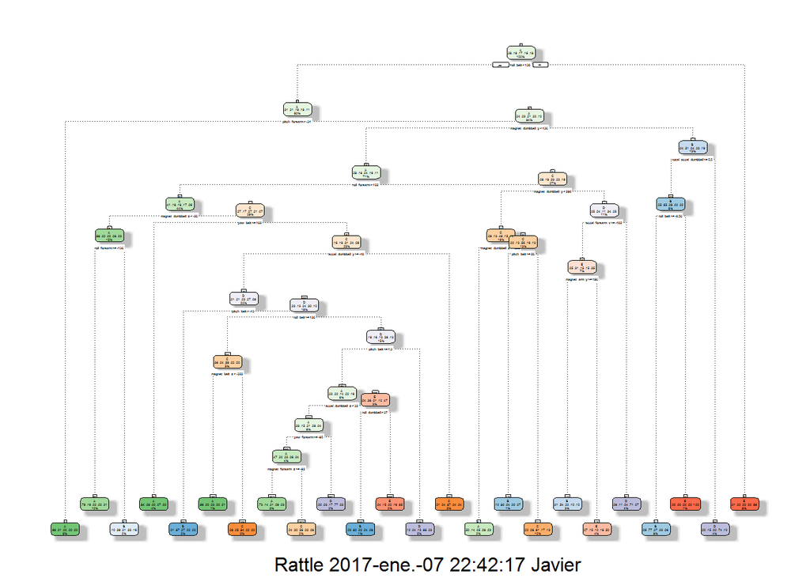

Now we apply the model to myTesting data

```r
predictionDecTree <- predict(modDecTree, myTesting, type="class")
cmDecTree <- confusionMatrix(predictionDecTree, myTesting$classe)
cmDecTree
```

```
## Confusion Matrix and Statistics
##
##           Reference
## Prediction   A   B   C   D   E
##          A 982 125  25  39  24
##          B  41 466  62  63  64
##          C  25  78 528  96  74
##          D  45  59  46 404  43
##          E  23  31  23  41 516
##
## Overall Statistics
##
##                Accuracy : 0.7382
##                  95% CI : (0.7242, 0.7519)
##     No Information Rate : 0.2845
##     P-Value [Acc > NIR] : < 2.2e-16
##
##                   Kappa : 0.6681
##  Mcnemar's Test P-Value : < 2.2e-16
##
## Statistics by Class:
##
##                      Class: A Class: B Class: C Class: D Class: E
## Sensitivity            0.8799   0.6140   0.7719   0.6283   0.7157
## Specificity            0.9241   0.9273   0.9157   0.9412   0.9631
## Pos Pred Value         0.8218   0.6695   0.6592   0.6767   0.8139
## Neg Pred Value         0.9509   0.9092   0.9500   0.9281   0.9377
## Prevalence             0.2845   0.1935   0.1744   0.1639   0.1838
## Detection Rate         0.2503   0.1188   0.1346   0.1030   0.1315
## Detection Prevalence   0.3046   0.1774   0.2042   0.1522   0.1616
## Balanced Accuracy      0.9020   0.7706   0.8438   0.7847   0.8394
```

The calculated accuracy is 0.7382106.

## Model 2: Random forest

Usually random forest is one of the most accurated methods.

```r
modRanForest <- randomForest(classe~., data=myTraining)
predictionRanForest <- predict(modRanForest, myTesting, type="class")
cmRanForest <- confusionMatrix(predictionRanForest, myTesting$classe)
cmRanForest
```

```
## Confusion Matrix and Statistics
##
##           Reference
## Prediction    A    B    C    D    E
##          A 1115    4    0    0    0
##          B    1  752    4    0    0
##          C    0    3  680    5    0
##          D    0    0    0  637    1
##          E    0    0    0    1  720
##
## Overall Statistics
##
##                Accuracy : 0.9952
##                  95% CI : (0.9924, 0.9971)
##     No Information Rate : 0.2845
##     P-Value [Acc > NIR] : < 2.2e-16
##
##                   Kappa : 0.9939
##  Mcnemar's Test P-Value : NA
##
## Statistics by Class:
##
##                      Class: A Class: B Class: C Class: D Class: E
## Sensitivity            0.9991   0.9908   0.9942   0.9907   0.9986
## Specificity            0.9986   0.9984   0.9975   0.9997   0.9997
## Pos Pred Value         0.9964   0.9934   0.9884   0.9984   0.9986
## Neg Pred Value         0.9996   0.9978   0.9988   0.9982   0.9997
## Prevalence             0.2845   0.1935   0.1744   0.1639   0.1838
## Detection Rate         0.2842   0.1917   0.1733   0.1624   0.1835
## Detection Prevalence   0.2852   0.1930   0.1754   0.1626   0.1838
## Balanced Accuracy      0.9988   0.9946   0.9958   0.9952   0.9992
```

The calculated accuracy is 0.9951568

So, this method is better than previous.

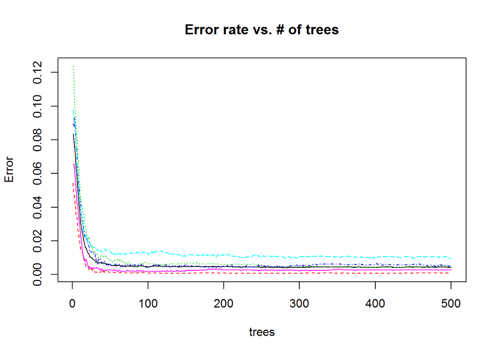

```r
plot(modRanForest, main="Error rate vs. # of trees")
```

And the six most important predictors are:

```r
vi<- varImp(modRanForest)
vi$variables<-row.names(vi)
vi<- arrange(vi, desc(Overall))
head(vi)
```

```
##     Overall         variables
## 1 1042.1851         roll_belt
## 2  708.9822          yaw_belt
## 3  617.0234     pitch_forearm
## 4  606.7783 magnet_dumbbell_z
## 5  565.0737 magnet_dumbbell_y
## 6  552.5303        pitch_belt
```

# Applying Random Forest model to Test Data

We apply this model to the original test data. First, we make the same cleaning and transforming.

```r
#Removing X and user_name columns
testing <- testing %>% select(-X) %>% select (-user_name)

#Removing timestamp and window columns not contains sensor measurement data
testing <- testing %>% select(-contains("window")) %>% select(-contains("timestamp"))

#Determining Near Zero Variance Variables
nearzerovars<- nearZeroVar(testing, saveMetrics = TRUE)
testing<- testing[,nearzerovars$nzv==FALSE]


#Last, we drop columns with all o majority NA values
variableNAs <- colMeans(is.na(testing))
testing <- testing[!variableNAs]

# Prediction

predictionRanForestTest <- predict(modRanForest, testing, type="class")
predictionRanForestTest
```

```
##  1  2  3  4  5  6  7  8  9 10 11 12 13 14 15 16 17 18 19 20
##  B  A  B  A  A  E  D  B  A  A  B  C  B  A  E  E  A  B  B  B
## Levels: A B C D E
```